# Homework 2

```r
   load("../data/RainData.RData")

library(ggplot2)
library(gstat)
library(sf)
```

# ANNO 1973

## Weak prompt

I wrote a weak prompt by only giving the instructions and some context about the data. For explanatory analysis, Claude Sonnet fitted a linear regression of the amount of rainfall on the the elevation, the latitude and the longitude, which doesn’t make much sense. It also provided plots of rainfall with respect to latitude and longitude, that were giving interesting information but information that could have been better seen on a map. On top of that it didn’t provide code for a semi-variogram which is essential for analyzing spatial dependence on continuous data. Other than that, the choice of p by cross-validation and the interpolation map are already quite good with the first prompt. With the second prompt Claude is giving indication on how to interpret the results, which is good.

Other than that, the choice of p by cross-validation and the interpolation map are already quite good with the first prompt.

## Good prompt

> I work on a spatial data on rainfall and have measures from several stations in Italy, I will only study the year 1973. Code in R in cells that can be added in a quarto document. Follow these instructions : 1. Run an exploratory data analysis on the rainfall itself. Analyze the relationship between the amount of rain and the elevation. Do basic bivariate analysis (scatter plot with a line corresponding to the linear model, measure of correlation and hypothesis test). Also do a map of the rainfall and a semi-variogram. 2. Using cross-validation, choose the optimal value for p in the IDW estimator, with respect to the MSE . 3. Using the IDW estimator and the optimal p, map the variable of interest on the grid given prediction grid (which is stored in gridXUTM and gridYUTM).

> Preferences: * Use XUTM/YUTM for both stations and grid, in EPSG:32632, with no reprojection. * For each conclusion done let me a way to assess the result

> Data * dati73 is a data.frame with columns totanno (annual rainfall, mm), Quota (elevation, m), Lat10/Lon10 (WGS84 degrees), XUTM/YUTM (metres, EPSG:32632), and anno (year). It originally has 2373 rows (about 190 stations over several years). I have already filtered it to a single year, so it now has one row per station and no duplicated coordinates. * grid is a data.frame with columns XUTM and YUTM. It has 1005 rows and is not a regular grid: every point has unique X and Y values, with irregular spacing. Please plot it as points, not with geom_tile/geom_raster.
1. **Exploratory data analysis**

**1.1 Distribution of annual rainfall**

```r
dati73 <- dati |>
  dplyr::filter(dati$anno == 1973)

summary(dati73$totanno)
```

```
   Min. 1st Qu.  Median    Mean 3rd Qu.    Max.
  464.9   854.4  1155.1  1241.5  1581.9  2757.6
```

```r
cat("SD:", sd(dati73$totanno), "| CV:", sd(dati73$totanno) / mean(dati73$totanno), "\n")
```

```
SD: 464.2054 | CV: 0.3739103
```

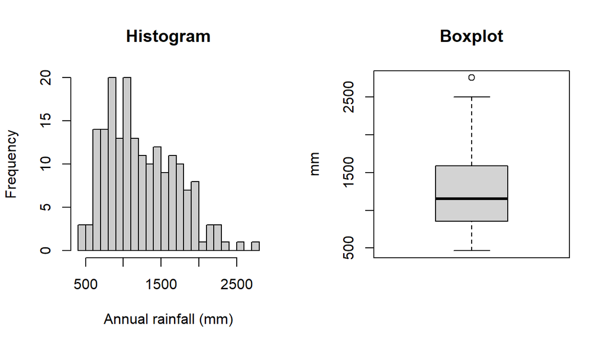

```r
op <- par(mfrow = c(1, 2))
hist(dati73$totanno, breaks = 20, col = "grey80", main = "Histogram", xlab = "Annual rainfall (mm)")
boxplot(dati73$totanno, main = "Boxplot", ylab = "mm")
```

```r
par(op)
```

The annual rainfall ranges from 465 to 2758 with a mean and a median not very far one from the other (around 1200 mm). Let’s analyze how is the rainfall linked to the elevation.

**1.2 Rainfall vs elevation**

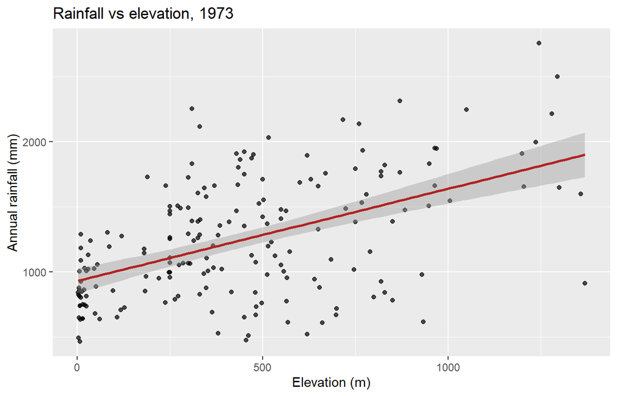

```r
ggplot(dati73, aes(Quota, totanno)) +
  geom_point(alpha = 0.7) +
  geom_smooth(method = "lm", se = TRUE, colour = "firebrick") +
  labs(x = "Elevation (m)", y = "Annual rainfall (mm)",
       title = "Rainfall vs elevation, 1973")
```

```r
# correlation measures and tests
ct_p <- cor.test(dati73$Quota, dati73$totanno, method = "pearson")
ct_p
```

```
    Pearson's product-moment correlation

data:  dati73$Quota and dati73$totanno
t = 8.0518, df = 186, p-value = 9.467e-14
alternative hypothesis: true correlation is not equal to 0
95 percent confidence interval:
 0.3939471 0.6073189
sample estimates:
      cor
0.5083951
```

```r
# simple linear model
fit_lm <- lm(totanno ~ Quota, data = dati73)
summary(fit_lm)
```

```
Call:
lm(formula = totanno ~ Quota, data = dati73)

Residuals:
   Min     1Q Median     3Q    Max
-987.5 -285.3  -48.2  261.9 1104.2

Coefficients:
            Estimate Std. Error t value Pr(>|t|)
(Intercept) 930.6927    48.4195  19.221  < 2e-16 ***
Quota         0.7086     0.0880   8.052 9.47e-14 ***
---
Signif. codes:  0 '***' 0.001 '**' 0.01 '*' 0.05 '.' 0.1 ' ' 1

Residual standard error: 400.8 on 186 degrees of freedom
Multiple R-squared:  0.2585,    Adjusted R-squared:  0.2545
F-statistic: 64.83 on 1 and 186 DF,  p-value: 9.467e-14
```

```r
confint(fit_lm)
```

```
                  2.5 %       97.5 %
(Intercept) 835.1706555 1026.2147472
Quota         0.5349559    0.8821721
```

A scatter plot shows a positive trend, which is confirmed with the Pearson’s correlation test. The correlation is around 0.5. The F-statistic of linear model performed states that taking account the elevation improves the R squared. Both the intercept and the slope are statistically significants, with this time a slope reaching 0.7.

```r
shapiro.test(residuals(fit_lm))
```

```
    Shapiro-Wilk normality test

data:  residuals(fit_lm)
W = 0.99469, p-value = 0.7449
```

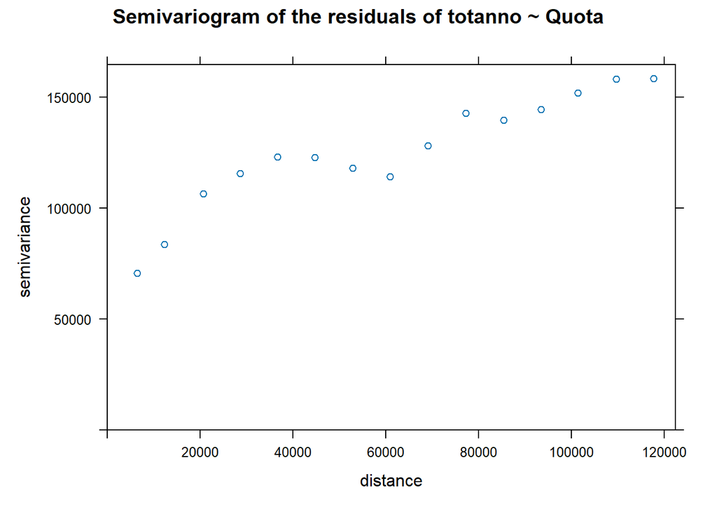

```r
# is there leftover spatial structure in the residuals?
dati73$res_lm <- residuals(fit_lm)
vr <- variogram(res_lm ~ 1, locations = ~ XUTM + YUTM, data = dati73)
plot(vr, main = "Semivariogram of the residuals of totanno ~ Quota")
```

The shapiro wilk test confirms the normality of the residuals of the regression, which is necessary for trusting the p-values. Though, as the semi-variogram of the the reiduals of the regression shows a variance growing with the distance, it should be kept in mind that elevation is not explaining all the spatial dependence.

1.3 Map of the rainfall

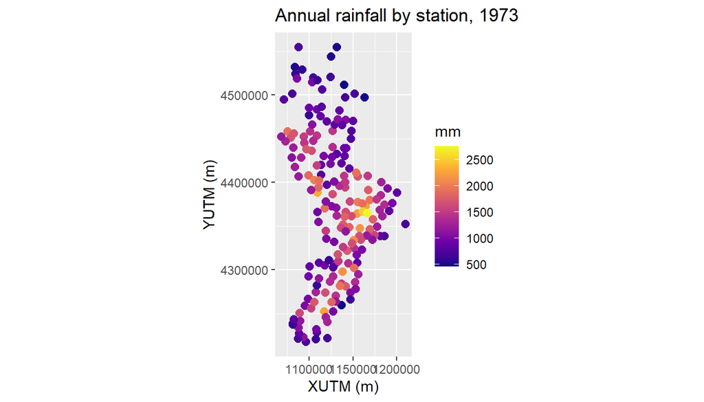

```r
ggplot(dati73, aes(XUTM, YUTM, colour = totanno)) +
  geom_point(size = 2.5) +
  scale_colour_viridis_c(option = "C", name = "mm") +
  coord_equal() +
  labs(x = "XUTM (m)", y = "YUTM (m)", title = "Annual rainfall by station, 1973")
```

A map of rainfall in the stations allows seeing a spatial dependence. It can be clearly seen that there is one zone with larger amounts of rainfall during year 1973. The coastal areas also seem to get less rain.

1.4 Empirical semivariogram

```r
v <- variogram(totanno ~ 1, locations = ~ XUTM + YUTM, data = dati73)
v
```

```
    np       dist    gamma dir.hor dir.ver   id
1   92   6457.583  82662.8       0       0 var1
2  400  12342.504 117282.7       0       0 var1
3  574  20688.138 151130.9       0       0 var1
4  762  28692.817 174031.8       0       0 var1
5  880  36646.746 194646.1       0       0 var1
6  899  44771.900 192792.8       0       0 var1
7  911  52883.879 194780.3       0       0 var1
8  906  60959.595 179389.8       0       0 var1
9  926  69107.206 202525.3       0       0 var1
10 855  77247.492 212809.8       0       0 var1
11 830  85372.704 220387.2       0       0 var1
12 771  93472.489 216042.0       0       0 var1
13 720 101406.114 234398.3       0       0 var1
14 742 109705.790 230992.3       0       0 var1
15 682 117745.137 232861.7       0       0 var1
```

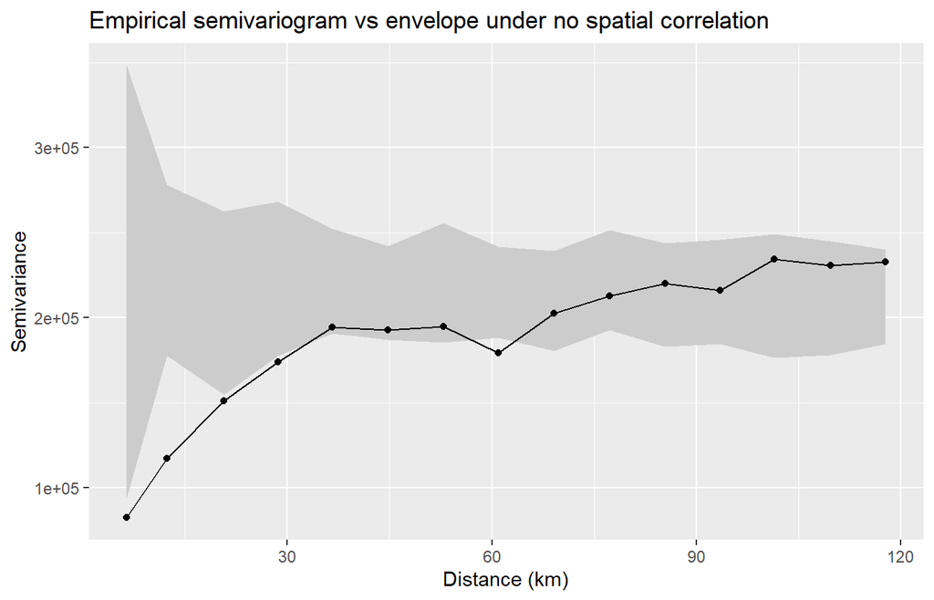

```r
# Monte Carlo envelope under spatial independence: permute the values over the stations
set.seed(1973)
nsim <- 99
sims <- replicate(nsim, {
  tmp <- dati73
  tmp$totanno <- sample(tmp$totanno)
  variogram(totanno ~ 1, locations = ~ XUTM + YUTM, data = tmp,
            cutoff = max(v$dist) / 0.95 * 0.95, width = v$dist[2] - v$dist[1])$gamma[seq_len(nrow(v))]
})
env <- data.frame(dist = v$dist, gamma = v$gamma,
                  lo = apply(sims, 1, min, na.rm = TRUE),
                  hi = apply(sims, 1, max, na.rm = TRUE))

ggplot(env, aes(dist / 1000)) +
  geom_ribbon(aes(ymin = lo, ymax = hi), fill = "grey80") +
  geom_point(aes(y = gamma)) + geom_line(aes(y = gamma)) +
  labs(x = "Distance (km)", y = "Semivariance",
       title = "Empirical semivariogram vs envelope under no spatial correlation")
```

There are observed points below the ribbon at short lags, this means that nearby stations are more similar than chance allows, so there is positive spatial correlation. This is the typical, expected pattern for rainfall.

2. Choice of p

   Now, let’s do choose p for the IDW. The IDW estimator at point $s_0$ is

$$\hat z(s_0)=\frac{\sum_i d(s_0,s_i)^{-p} z(s_i)}{\sum_i d(s_0,s_i)^{-p}}.$$

For each station $i$ I remove it, predict it from the other $n-1$, and compute $\mathrm{MSE}(p)=\frac1n\sum_i(z_i-\hat z_{-i})^2$.

```r
X <- cbind(dati73$XUTM, dati73$YUTM)
z <- dati73$totanno
n <- length(z)
D <- as.matrix(dist(X))
diag(D) <- Inf                       # leave-one-out: a station never predicts itself

cv_mse <- function(p) {
  W <- 1 / D^p                       # Inf^p = Inf -> weight 0 on the diagonal
  pred <- as.vector(W %*% z) / rowSums(W)
  mean((z - pred)^2)
}

p_grid <- seq(0.25, 8, by = 0.25)
cv <- data.frame(p = p_grid, MSE = sapply(p_grid, cv_mse))

# refine around the minimum of the coarse grid
p0 <- cv$p[which.min(cv$MSE)]
opt <- optimize(cv_mse, interval = c(max(0.01, p0 - 0.25), p0 + 0.25))
p_opt <- opt$minimum
cat("Optimal p:", round(p_opt, 3), "| CV MSE:", round(opt$objective, 1),
    "| CV RMSE:", round(sqrt(opt$objective), 1), "mm\n")
```

```
Optimal p: 3.125 | CV MSE: 95759.6 | CV RMSE: 309.5 mm
```

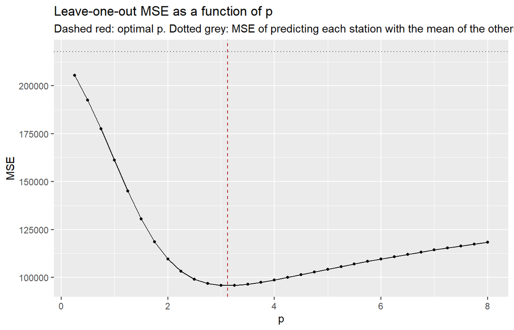

```r
ggplot(cv, aes(p, MSE)) +
  geom_line() + geom_point(size = 1) +
  geom_vline(xintercept = p_opt, linetype = 2, colour = "firebrick") +
  geom_hline(yintercept = var(z) * n / (n - 1)^2 * n, linetype = 3, colour = "grey40") +
  labs(title = "Leave-one-out MSE as a function of p",
       subtitle = "Dashed red: optimal p. Dotted grey: MSE of predicting each station with the mean of the others")
```

The value of p that minimizes the MSE is 3.125, this is the value that is kept for the interpolation.

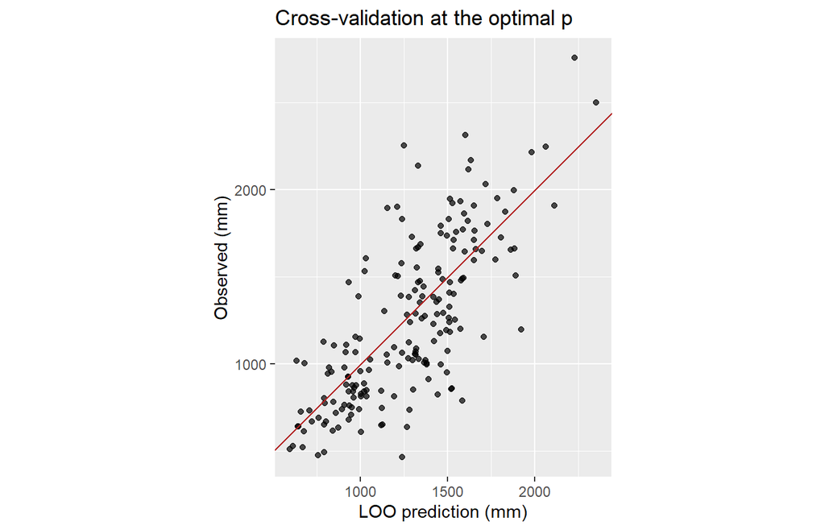

```r
# observed vs predicted at p_opt
W <- 1 / D^p_opt
cv_pred <- as.vector(W %*% z) / rowSums(W)

ggplot(data.frame(obs = z, pred = cv_pred), aes(pred, obs)) +
  geom_point(alpha = 0.7) +
  geom_abline(slope = 1, intercept = 0, colour = "firebrick") +
  coord_equal() +
  labs(x = "LOO prediction (mm)", y = "Observed (mm)", title = "Cross-validation at the optimal p")
```

```r
# skill with respect to the trivial predictor (mean of the other stations)
mse_mean <- mean((z - (sum(z) - z) / (n - 1))^2)
cat("MSE IDW:", round(opt$objective, 1), "| MSE mean-of-others:", round(mse_mean, 1),
    "| relative skill:", round(1 - opt$objective / mse_mean, 3), "\n")
```

```
MSE IDW: 95759.6 | MSE mean-of-others: 216639 | relative skill: 0.558
```

```r
cat("Correlation obs vs LOO prediction:", round(cor(z, cv_pred), 3), "\n")
```

```
Correlation obs vs LOO prediction: 0.747
```

3. IDW map on the prediction grid

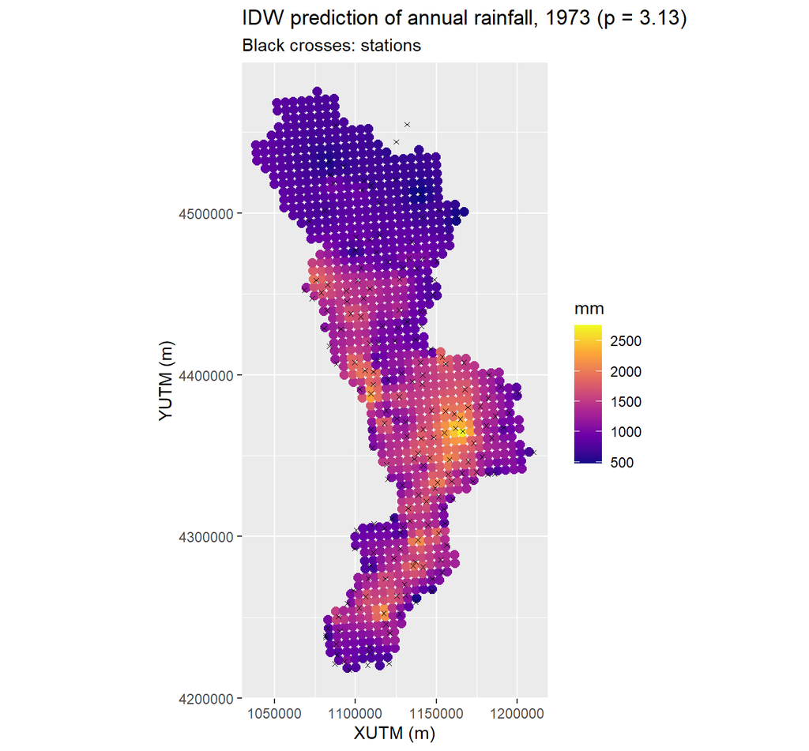

```r
idw_predict <- function(x0, y0, x, y, z, p) {
  d <- sqrt(outer(x0, x, "-")^2 + outer(y0, y, "-")^2)
  d[d < 1e-6] <- 1e-6                # a grid point on a station returns (almost exactly) that station's value
  W <- 1 / d^p
  as.vector(W %*% z) / rowSums(W)
}

grid$pred <- idw_predict(grid$XUTM, grid$YUTM, dati73$XUTM, dati73$YUTM, dati73$totanno, p_opt)

# distance of each grid point to the nearest station (for diagnostics)
grid$d_nn <- apply(sqrt(outer(grid$XUTM, dati73$XUTM, "-")^2 + outer(grid$YUTM, dati73$YUTM, "-")^2), 1, min)

ggplot() +
  geom_point(data = grid, aes(XUTM, YUTM, colour = pred), size = 2.5) +
  geom_point(data = dati73, aes(XUTM, YUTM), shape = 4, colour = "black", size = 1) +
  scale_colour_viridis_c(option = "C", name = "mm") +
  coord_equal() +
  labs(x = "XUTM (m)", y = "YUTM (m)",
       title = paste0("IDW prediction of annual rainfall, 1973 (p = ", round(p_opt, 2), ")"),
       subtitle = "Black crosses: stations")
```

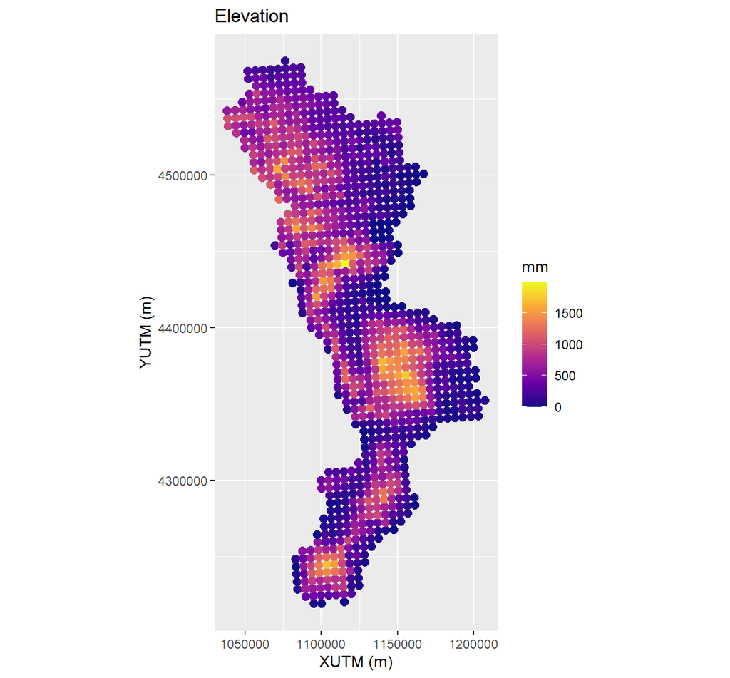

```r
ggplot()+
  geom_point(data= grid, aes(XUTM, YUTM, colour = Quota), size = 2.5) +
  scale_colour_viridis_c(option = "C", name = "mm") +
  coord_equal() +
  labs(x = "XUTM (m)", y = "YUTM (m)",
       title = "Elevation ")
```

# Anno 1974

For having only the results of the homework on this notebook, we use a R file where we put all the functions needed for this work and then we can use them thanks to the source function. The content of this R file and the AI prompts used to generate functions will be analyzed at this end of this notebook.

```r
source("../Travail_Christophe/homework-2/Useful_functions.R")
```

In a first time, we create a new dataset with only the observations made in 1974 thanks to the filter_target function.

```r
data_1974 <- filter_target(data = dati,
                           variable = "anno",
                           target = 1974)
```

## Question 1

1) Run an exploratory data analysis and comment on the results. In particular, analyze the relationship between the dependent variable (for example, total amount of rainfall, biomass, metal concentration) and the environmental descriptors.

First of all, we analyse quickly the diverse variables available in the data and we create a map with the localisation of the diverse observations.

```r
board <- summary_statistics(data_1974)

knitr::kable(board, digits = 2)
```

| Variable | Minimum | Q1 | Mediane | Moyenne | Q3 | Maximum |
| --- | --- | --- | --- | --- | --- | --- |
| ID | 4071.00 | 4181.00 | 4261.00 | 4260.55 | 4340.50 | 4428.00 |
| ID1 | 754.00 | 800.50 | 847.00 | 847.00 | 893.50 | 940.00 |
| Lat10 | 37.92 | 38.68 | 39.27 | 39.28 | 39.87 | 40.93 |
| Lon10 | 15.63 | 16.05 | 16.29 | 16.29 | 16.51 | 17.20 |
| Quota | 2.00 | 204.50 | 380.00 | 438.17 | 645.00 | 1369.00 |
| XUTM | 1068405.88 | 1107743.53 | 1127694.95 | 1128781.39 | 1148503.47 | 1210196.03 |
| YUTM | 4217444.12 | 4306662.16 | 4372759.81 | 4373067.08 | 4438335.16 | 4554706.52 |
| anno | 1974.00 | 1974.00 | 1974.00 | 1974.00 | 1974.00 | 1974.00 |
| totanno | 300.55 | 657.48 | 907.87 | 973.21 | 1229.09 | 2425.81 |

```r
map_observations(
  data = data_1974,
  var_lon = "Lon10",
  var_lat = "Lat10"
)
```

[interactive chart not shown]

Then,we analyze the relationship between the dependent variable (totanno) and the environmental descriptors.

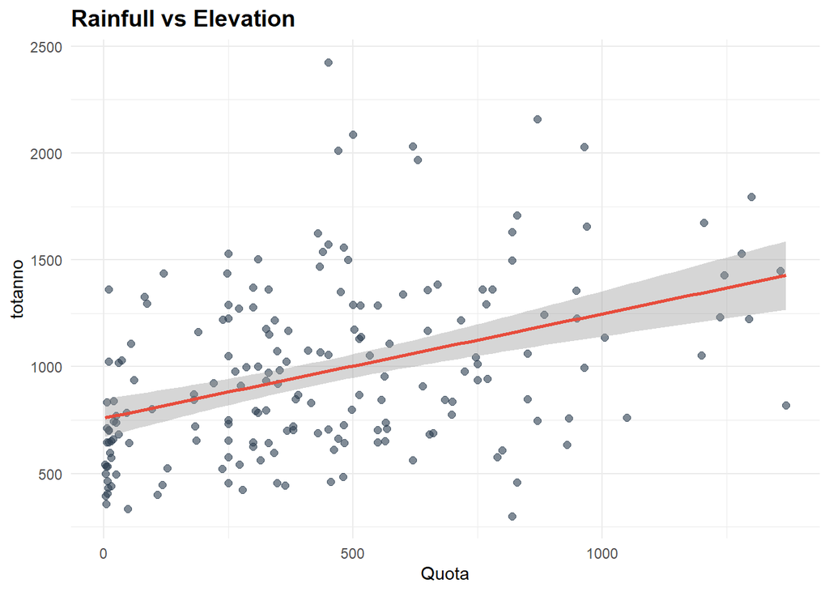

```r
double_graphic(
  dataset = data_1974,
  var_y = "totanno",
  var_x = "Quota",
  titre = "Rainfull vs Elevation"

)
```

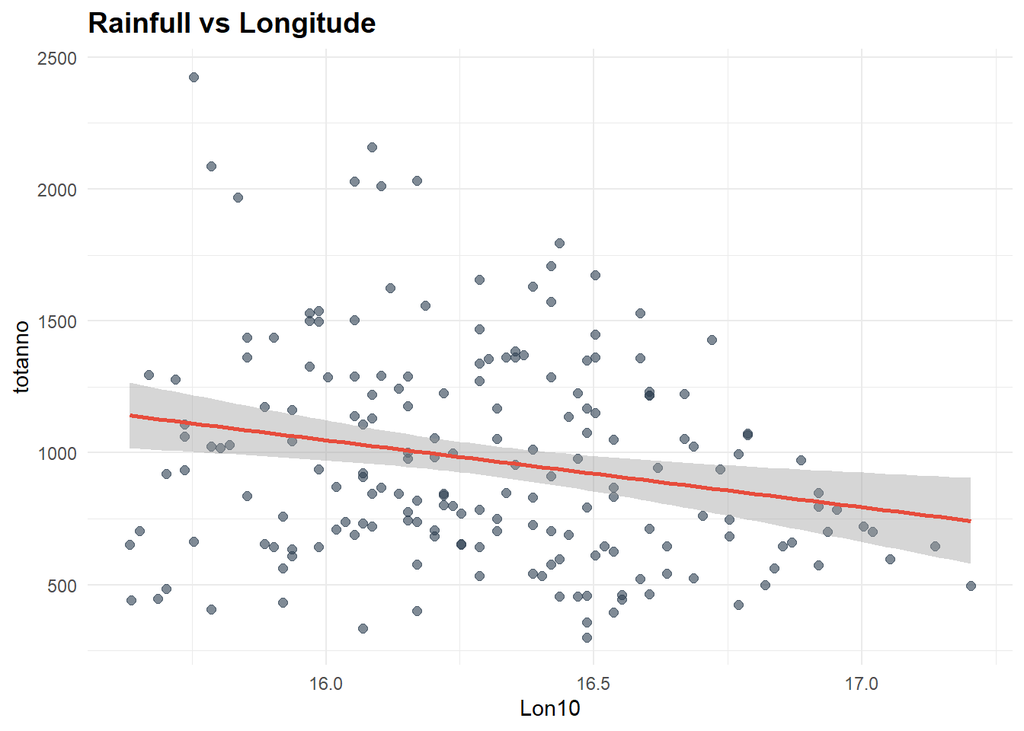

```r
double_graphic(
  dataset = data_1974,
  var_y = "totanno",
  var_x = "Lon10",
  titre = "Rainfull vs Longitude"

)
```

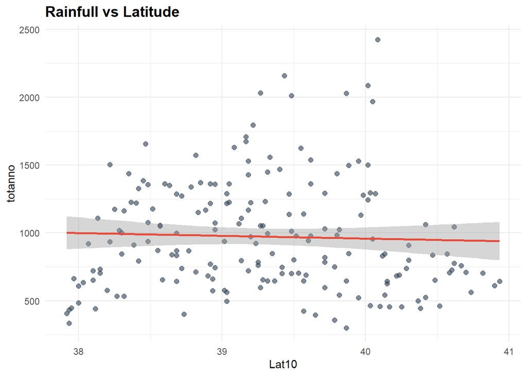

```r
double_graphic(
  dataset = data_1974,
  var_y = "totanno",
  var_x = "Lat10",
  titre = "Rainfull vs Latitude"

)
```

Finally, we analyze spatial dependence using a variogram. We use the variables XUTM and YUTM to calculate the distance between the points where the observations in the dataset were taken.

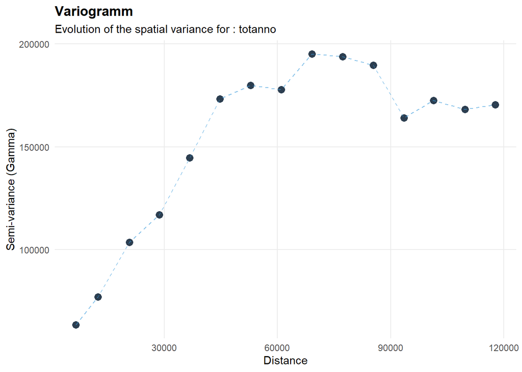

```r
variogramm(
  data = data_1974,
  var_x = "XUTM",
  var_y = "YUTM",
  var_output = "totanno",
  code_epsg = 32632
)
```

The semi-variance increases very quickly before reaching a cap as expected.

## Question 2

2) Using cross-validation, choose the optimal value for p in the IDW estimator.

```
 The optimal parameter p totanno is : 3.5
```

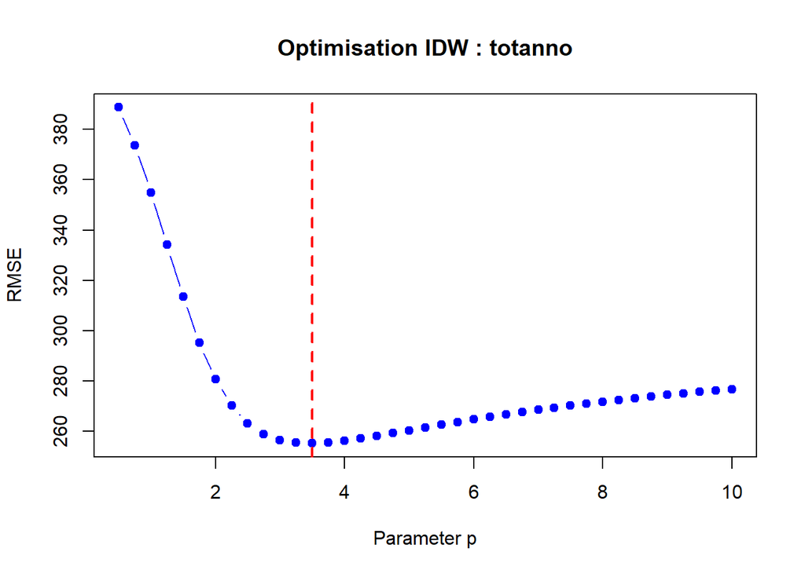

```r
results_opti <- optimise_p_idw(data = data_1974,
                                  var_x = "XUTM",
                                  var_y = "YUTM",
                                  var_output = "totanno",
                                  code_epsg = 32632)
```

## Question 3

3. Using the IDW estimator and the optimal p, map the variable of interest on the grid given prediction grid.

We upload the map of Italy for the grid

```r
install.packages(c("rnaturalearth", "rnaturalearthdata"))
```

```r
library(rnaturalearth)

borders_italie <- ne_countries(scale = "medium", country = "Italy", returnclass = "sf")
```

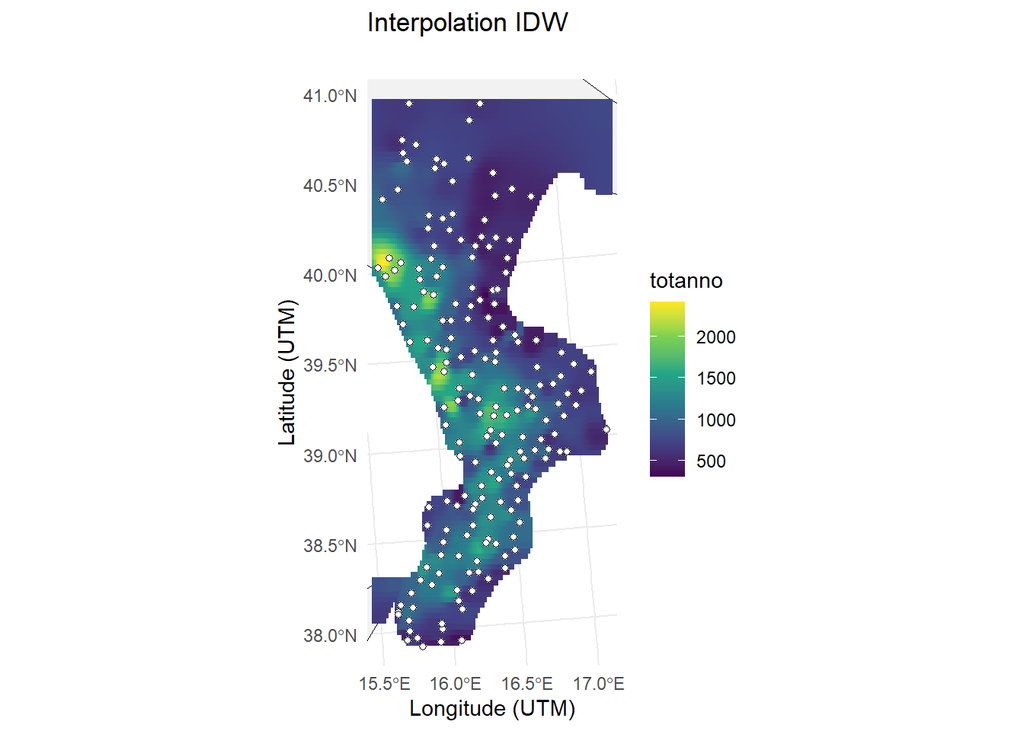

```r
grid_idw(
  data = data_1974,
  var_x = "XUTM",
  var_y = "YUTM",
  var_output = "totanno",
  code_epsg = 32632,
  param_p = 3.5,
  map = borders_italie
)
```

## Question 4

4. provide the AI prompt in weak and good form

AI used : Gemini Pro

Prompt : OK, now I’d like a function that takes as arguments a dataset, a first variable, then a second variable from that dataset, and a title, and that returns a graph with the values of the first variable on the y-axis and those of the second variable on the x-axis.

```r
double_graphic <- function(dataset, var_y, var_x, titre) {

  ggplot(data = dataset, aes(x = .data[[var_x]], y = .data[[var_y]])) +

    geom_point(color = "#2c3e50", size = 2, alpha = 0.6) +
    geom_smooth(method = "lm", color = "#e74c3c", se = TRUE) +

    labs(
      title = titre,
      x = var_x,
      y = var_y
    ) +


    theme_minimal() +
    theme(
      plot.title = element_text(face = "bold", size = 14)
    )
}
```

Comment : With the first prompt, the function allowed just to see the coordinates of the diverse points and did not show the correlation between the two variables. So I add the line “geom_smooth(method =”lm”, color = “#e74c3c”, se = TRUE) +” to show the correlation thanks to the folllowing prompt : Okay, I’d like you to add a trend line to this graph showing the correlation between the two variables used as arguments.

Prompt : I want a function that takes a dataset, a first variable, and then a second variable as arguments. The first variable represents the longitude of the observation, and the second variable represents the latitude of the observation. Based on these variables, the function should return a map showing the locations of the various observations in the dataset provided as an argument.

```r
map_observations <- function(dataset, var_lon, var_lat) {

  leaflet(data = dataset) |>
    # addTiles() adds the map (OpenStreetMap)
    addTiles() |>
    # addCircleMarkers adds a point for each observation
    addCircleMarkers(
      lng = dataset[[var_lon]],
      lat = dataset[[var_lat]],
      radius = 5,                 # size of points
      color = "#FF5733",          # Color
      stroke = FALSE,             # no border
      fillOpacity = 0.7,          # Opacity
      # bonus : interactive map
      popup = paste("Lon:", dataset[[var_lon]], "<br>Lat:", dataset[[var_lat]])
    )
}
```

Comment : This prompt allowed me to have directly the result expected.

Prompt : I’m working in spatial statistics and I have to analyse a dataset. Create a function that takes as arguments a dataset, a first variable, a second variable, and a third variable. The first variable holds the XUTM values, the second the YUTM values, and the third the output I’m working on. I want the program to calculate the distance between the different points in order to create a variogram that shows how the correlation of the output changes as the distance changes.

```r
variogramm <- function(dataset, var_x, var_y, var_output, code_epsg) {

  # 1. Spatial transformation (in meters using UTM)
  dataset_sf <- st_as_sf(dataset, coords = c(var_x, var_y), crs = code_epsg)

  # 2. Dynamic formula creation (e.g., "My_Output ~ 1")
  # "~ 1" means we are studying the raw variable, without external trend
  formule <- as.formula(paste(var_output, "~ 1"))

  # 3. Calculation of the experimental variogram
  # gstat automatically calculates distances and groups points into bins
  vario_exp <- variogram(formule, data = dataset_sf)

  # 4. Graph creation with ggplot2
  ggplot(vario_exp, aes(x = dist, y = gamma)) +
    geom_point(color = "#2c3e50", size = 3) +
    geom_line(color = "#3498db", linetype = "dashed", alpha = 0.6) +
    labs(
      title = "Variogramm",
      subtitle = paste("Evolution of the spatial variance for :", var_output),
      x = "Distance",
      y = "Semi-variance (Gamma)"
    ) +
    theme_minimal() +
    theme(
      plot.title = element_text(face = "bold"),
      panel.grid.minor = element_blank()
    )
}
```

Comment : This prompt allowed me to have directly the result expected.

Prompt : I want a function that finds the optimal parameter p for the weighted inverse distance estimator and that takes as arguments the dataset and two variables—the first representing the XUTM coordinate and the second representing the YUTM coordinate.

```r
optimise_p_idw <- function(dataset, var_x, var_y, var_output, code_epsg) {

  # 1. Spatial conversion with dynamic variables
  dataset_sf <- st_as_sf(dataset, coords = c(var_x, var_y), crs = code_epsg)

  # 2. Dynamic formula creation
  formule <- as.formula(paste(var_output, "~ 1"))

  # 3. Parameter initialization
  p_values <- seq(0.5, 10.0, by = 0.25)

  rmse_results <- numeric(length(p_values))

  # 4. Outer loop: Testing different power parameters
  for (i in seq_along(p_values)) {
    current_p <- p_values[i]
    squared_errors <- numeric(nrow(dataset_sf))

    # 5. Inner loop: Leave-One-Out Cross-Validation (LOOCV)
    for (j in 1:nrow(dataset_sf)) {
      train_data <- dataset_sf[-j, ]
      test_data  <- dataset_sf[j, ]

      idw_fit <- idw(
        formula = formule,
        locations = train_data,
        newdata = test_data,
        idp = current_p,
        debug.level = 0
      )

      # 6. Value extraction and error calculation
      predicted_val <- idw_fit$var1.pred

      # Using double brackets [[ ]] to extract
      # the value of the test column via its text name
      actual_val <- test_data[[var_output]]

      squared_errors[j] <- (predicted_val - actual_val)^2
    }


    rmse_results[i] <- sqrt(mean(squared_errors))
  }

  # 7. Identification of the optimal value

  results_df <- data.frame(Power = p_values, RMSE = rmse_results)
  optimal_p <- results_df$Power[which.min(results_df$RMSE)]

  cat("\n The optimal parameter p", var_output, "is :", optimal_p, "\n")

  # 8. Display diagnostic plot
  plot(results_df$Power, results_df$RMSE, type = "b", pch = 19, col = "blue",
       xlab = "Parameter p",
       ylab = "RMSE",
       main = paste("Optimisation IDW :", var_output))
  abline(v = optimal_p, col = "red", lty = 2, lwd = 2)

}
```

Comment : The first function generated by the AI used the MSE to choose the best parameter p. To comply with the course, I replace the MSE by the RMSE even if it does not change the final result.

Prompt : I want you to create a function for me that takes a dataset, an output variable, and a parameter as arguments, and returns a map with the predicted output values calculated using IDW based on the parameter provided as an argument.

```r
grid_idw <- function(dataset, var_x, var_y, var_output, code_epsg, param_p, map) {

  # 1. Spatial conversion of your data
  dataset_sf <- st_as_sf(dataset, coords = c(var_x, var_y), crs = code_epsg)

  # 2. Creation of the raw grid (the large bounding box)
  grille_vierge <- st_make_grid(dataset_sf, n = c(100, 100), what = "centers")
  grille_sf <- st_sf(geometry = grille_vierge)

  # 3. THE SCISSOR CUT (Clipping)
  # First ensure the mask has the same EPSG code as your data
  map <- st_transform(map, crs = code_epsg)

  # Keep only the grid points that fall "inside" the mask
  grille_clippee <- st_intersection(grille_sf, map)

  # 4. IDW Calculation (Only on solid ground!)
  formule <- as.formula(paste(var_output, "~ 1"))
  idw_resultat <- idw(
    formula = formule,
    locations = dataset_sf,
    newdata = grille_clippee, # Using the clipped grid
    idp = param_p,
    debug.level = 0
  )

  # 5. Map creation with borders in the background
  ggplot() +
    # Background layer: The border polygon (drawn in light gray)
    geom_sf(data = map, fill = "gray95", color = "black") +

    # Interpolation layer: The predicted points
    geom_sf(data = idw_resultat, aes(color = var1.pred), size = 3, shape = 15) +

    # Data layer: Your actual observations
    geom_sf(data = dataset_sf, color = "black", shape = 21, fill = "white", size = 1.5) +

    scale_color_viridis_c(name = paste(var_output), "Prediction\n") +
    labs(
      title = "Interpolation IDW",
      subtitle = "",
      x = "Longitude (UTM)",
      y = "Latitude (UTM)"
    ) +
    theme_minimal()
}
```

Comment : The first prompt returned a map of the whole of Italy, which made it impossible to analyse the prediction, as it focused on only part of that territory. That is why the following prompt was needed to achieve this function: “I’d like you to modify the previous code so that the map returned focuses solely on the area where predictions could be made”.

# Conclusion

For the future, using prompts with more information is needed. Indeed, in absence of enough information, the functions generated do not allow to have the results expected because there are too many shaded areas to produce the correct result.

# Year 1980

```r
library(ggplot2)
library(gstat)
load("../data/RainData.RData")          # adapt the path if needed
```

For this homework we work on the stations of the year 1980. The AI agent used for the two prompts is Claude Sonnet 5.5.

## Data preparation

We keep only the year 1980 and check that there is one row per station and no repeated coordinates.

```r
d80 <- subset(dati, anno == 1980)
nrow(d80)                       # one row per station
```

```
[1] 178
```

```r
anyDuplicated(d80[, c("XUTM", "YUTM")])
```

```
[1] 0
```

```r
table(d80$Nome_Regione)
```

```
Basilicata   Calabria     Puglia
        36        139          3
```

There are 178 stations, each one appears once, and no two stations share the same coordinates. The table gives the region written in the data: 36 stations in Basilicata, 139 in Calabria and 3 in “Puglia”.

The three “Puglia” stations are **kept**. The two in the north (latitude above 40°) are in the same hydrological area as Basilicata, and the one in the south is in Calabria. We create a new label `zona` that puts them in the right area. It is only used to describe the data; **all 178 stations are used** for the analysis.

```r
d80$zona <- as.character(d80$Nome_Regione)
nord <- d80$Nome_Regione == "Puglia" & d80$Lat10 > 40
d80$zona[nord] <- "Basilicata"
d80$zona[d80$Nome_Regione == "Puglia" & !nord] <- "Calabria"
table(d80$Nome_Regione, d80$zona)
```

```
             Basilicata Calabria
  Basilicata         36        0
  Calabria            0      139
  Puglia              2        1
```

```r
X <- cbind(d80$XUTM, d80$YUTM)  # metres, UTM 32N, no reprojection
z <- d80$totanno
n <- length(z)
D <- as.matrix(dist(X))
```

The table crosses the old label (rows) and the new one (columns): the 2 northern stations are now in Basilicata and the southern one is in Calabria. `X` contains the coordinates in metres (UTM zone 32N, used as they are), `z` the rainfall, and `D` the matrix of the distances between all the stations.

## Weak prompt

> Here are rainfall data for Italy (data.frame `dati`, columns totanno = annual rainfall, Quota = elevation, XUTM, YUTM = coordinates, anno = year) and a prediction grid `grid`. I study the year 1980. Do an exploratory analysis of the rainfall and its link with the descriptors, choose the p of the IDW estimator by cross-validation and map the predictions on the grid. Code in R.

**What the agent returned.** A regression of the rainfall on elevation, latitude and longitude, a few plots, a choice of p among whole values (1 to 5) by leave-one-out cross-validation with the MSE, and a map.

```r
fit_weak <- lm(totanno ~ Quota + Lat10 + Lon10, data = d80)
round(summary(fit_weak)$coefficients, 3)
```

```
            Estimate Std. Error t value Pr(>|t|)
(Intercept) 7173.844   2245.227   3.195    0.002
Quota          0.657      0.097   6.748    0.000
Lat10        -48.119     43.917  -1.096    0.275
Lon10       -274.266     95.851  -2.861    0.005
```

```r
loo_mse <- function(p) {
  Dl <- D; diag(Dl) <- Inf
  W <- Dl^(-p)
  mean((z - as.vector(W %*% z) / rowSums(W))^2)
}
cv_weak <- data.frame(p = 1:5, MSE = sapply(1:5, loo_mse))
cv_weak
```

```
  p      MSE
1 1 188804.9
2 2 135396.6
3 3 129586.2
4 4 139717.5
5 5 149873.1
```

```r
p_weak <- cv_weak$p[which.min(cv_weak$MSE)]
p_weak
```

```
[1] 3
```

The first table is the regression. The coefficient of `Quota` is 0.66 with a very small p-value: 100 m more of elevation goes with about 66 mm more rain. The coefficients of latitude and longitude are not easy to interpret (the latitude is not significant, p = 0.28), and there is no reason given for putting them in the model. The second table gives the cross-validation error (MSE) for p = 1 to 5. It is the smallest for p = 3, so the agent keeps p = 3.

**Comments.** The agent did what was asked, but:

- the regression uses elevation and coordinates together without explaining why;
- there is no variogram, which is the usual way to look at spatial dependence of a continuous variable;
- p is only searched among whole values, so the best value can be missed;
- the agent does not check whether IDW is better than a very simple prediction, and it does not say what to do with the three “Puglia” stations.

## Good prompt

> I work on annual rainfall measured at stations in southern Italy (Basilicata and Calabria), year 1980 only. Code in R, in chunks that can be pasted in a Quarto document. Data: `dati` (columns totanno = annual rainfall in mm, Quota = elevation in m, XUTM/YUTM = coordinates in metres, EPSG:32632, to be used as they are, anno, Nome_Regione, Lat10) and `grid`, an irregular prediction grid (XUTM, YUTM, Quota) that must be plotted as points. The three stations labelled Puglia must be kept: the two in the north behave like Basilicata, the one in the south like Calabria. 1. Exploratory analysis, short: distribution of the rainfall, relationship with elevation (scatter plot with the regression line, correlation, test), map of the stations. 2. Spatial dependence: empirical variograms of the rainfall, of the residuals after elevation and after elevation + coordinates; justify the maximum distance with the distribution of the distances between stations and the number of pairs per class, and check the independence case with a Monte Carlo envelope. 3. Choose p in the IDW estimator by leave-one-out cross-validation using the RMSE (a proper score), searching on a fine grid; compare with the trivial predictor (mean of the other stations). 4. Map the IDW predictions on `grid` with the optimal p. For each conclusion, give a way to check it, and say that evidence of spatial dependence does not by itself prove that IDW predicts well: this has to be shown with the cross-validation.

**Answer.** Here is the analysis asked for by this prompt.

### 1. Exploratory analysis

First the distribution of the rainfall.

```r
summary(z)
```

```
   Min. 1st Qu.  Median    Mean 3rd Qu.    Max.
  211.7   717.5  1004.3  1104.7  1429.2  2945.6
```

```r
c(SD = sd(z), CV = sd(z) / mean(z))
```

```
         SD          CV
484.7802636   0.4388356
```

```r
round(tapply(z, d80$zona, mean))      # mean rainfall by area
```

```
Basilicata   Calabria
      1035       1124
```

```r
table(d80$zona)
```

```
Basilicata   Calabria
        38        140
```

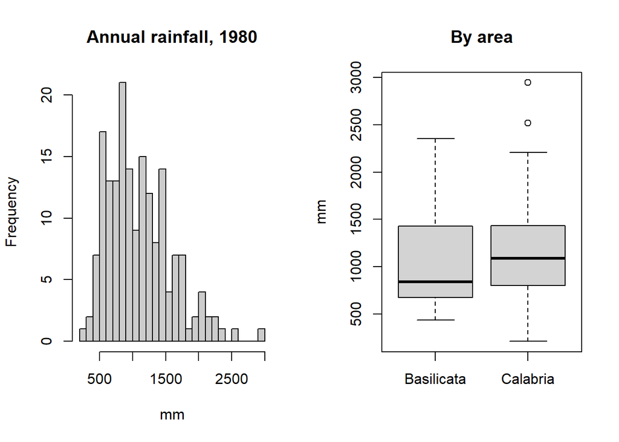

```r
par(mfrow = c(1, 2))
hist(z, breaks = 20, col = "grey80", main = "Annual rainfall, 1980", xlab = "mm")
boxplot(z ~ d80$zona, main = "By area", ylab = "mm", xlab = "")
```

```r
par(mfrow = c(1, 1))
```

*Figure: histogram of the annual rainfall (left) and boxplot by area (right).*

The rainfall goes from 212 mm to 2946 mm, with a mean of 1105 mm and a median of 1004 mm. The mean is above the median because a few stations receive a lot of rain (the histogram has a long tail on the right). The standard deviation is 485 mm, so the CV (standard deviation divided by the mean) is 0.44: the stations are very different from each other. The mean rainfall is similar in the two areas (1035 mm in Basilicata and 1124 mm in Calabria) and the boxplots overlap a lot, so we do not see a clear difference between areas. Besides, the stations are not spread in the same way in both areas, so a difference would not be enough to speak of a real regional effect.

Now the link with elevation.

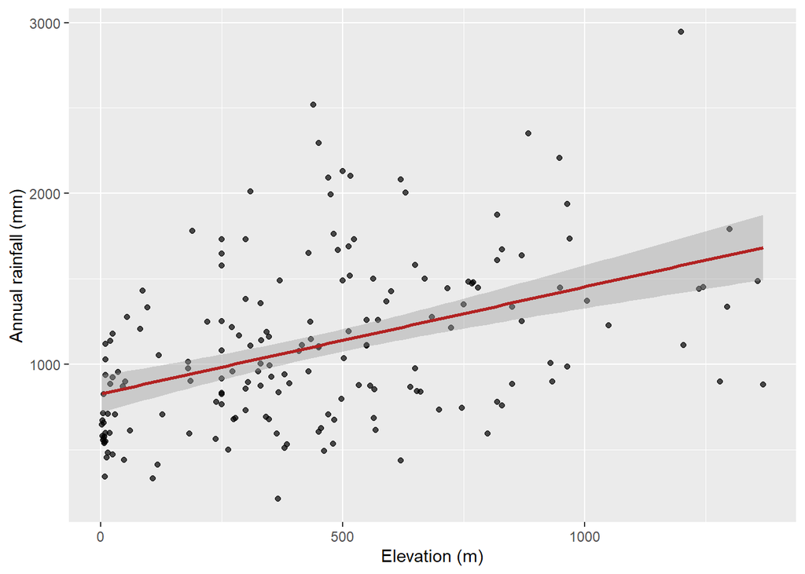

```r
ggplot(d80, aes(Quota, totanno)) +
  geom_point(alpha = 0.7) +
  geom_smooth(method = "lm", colour = "firebrick") +
  labs(x = "Elevation (m)", y = "Annual rainfall (mm)")
```

```r
ct_p <- cor.test(d80$Quota, d80$totanno)                        # Pearson
ct_p
```

```
    Pearson's product-moment correlation

data:  d80$Quota and d80$totanno
t = 6.3966, df = 176, p-value = 1.388e-09
alternative hypothesis: true correlation is not equal to 0
95 percent confidence interval:
 0.3068277 0.5464868
sample estimates:
     cor
0.434312
```

```r
ct_s <- cor.test(d80$Quota, d80$totanno, method = "spearman")  # rank-based check
ct_s
```

```
    Spearman's rank correlation rho

data:  d80$Quota and d80$totanno
S = 497130, p-value = 3.212e-11
alternative hypothesis: true rho is not equal to 0
sample estimates:
      rho
0.4710988
```

```r
fit_el <- lm(totanno ~ Quota, data = d80)
round(summary(fit_el)$coefficients, 4)
```

```
            Estimate Std. Error t value Pr(>|t|)
(Intercept) 827.7676    54.3291 15.2362        0
Quota         0.6258     0.0978  6.3966        0
```

```r
r2_el <- summary(fit_el)$r.squared
r2_el
```

```
[1] 0.1886269
```

*Figure: annual rainfall against elevation, with the regression line (red) and its confidence band.*

The points go up with elevation, but they are very spread around the line. The Pearson correlation is 0.43 (95 % interval from 0.31 to 0.55, p-value 1.4e-09). The test says that this correlation is not zero. The Spearman correlation, which only uses the ranks and is less sensitive to extreme values, gives the same message (0.47). In the regression, each additional 100 m of elevation adds about 63 mm of rain, and the coefficient is significant. But the R² is only 0.19: elevation explains about 19 % of the differences between stations. The rest is something else, probably the position of the station.

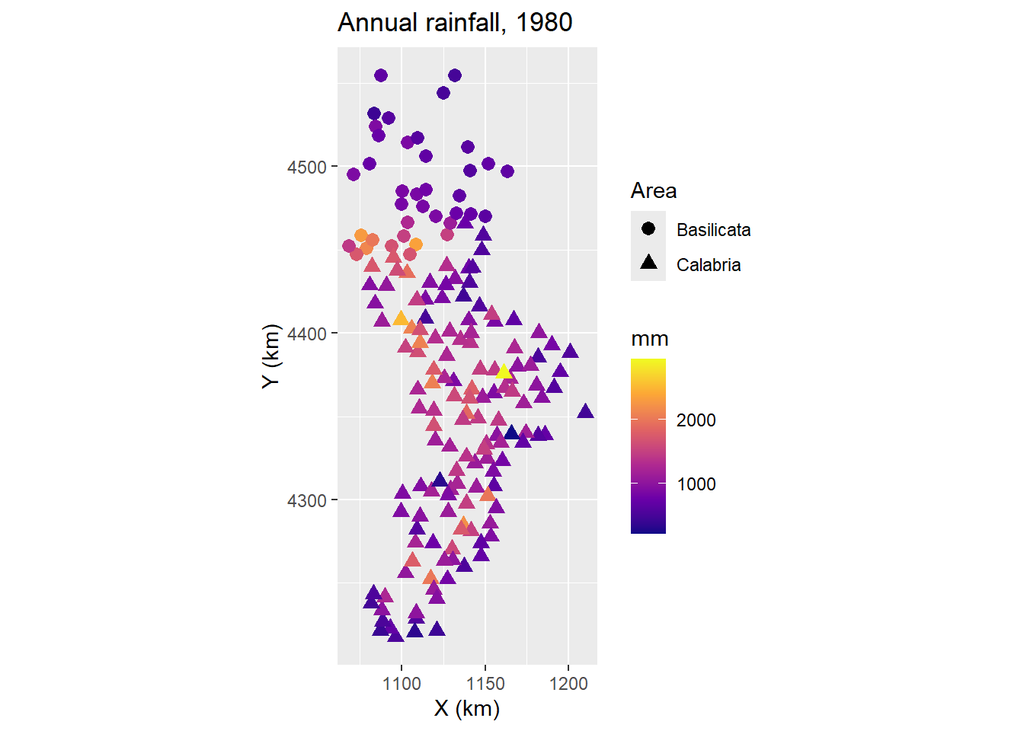

```r
ggplot(d80, aes(XUTM / 1000, YUTM / 1000, colour = totanno, shape = zona)) +
  geom_point(size = 2.8) +
  scale_colour_viridis_c(option = "C", name = "mm") +
  coord_equal() +
  labs(x = "X (km)", y = "Y (km)", shape = "Area", title = "Annual rainfall, 1980")
```

*Figure: map of the stations (x and y in km), colour = annual rainfall, shape = area.*

The stations are not regularly spread: there are groups of close stations and empty zones. The highest values (yellow) are grouped in some places and the lowest values (dark) in others, so the rainfall looks related to the location, which is what we study next.

### 2. Spatial dependence: variograms

The variogram compares the stations two by two: for each distance class, it gives the average of half the squared difference between the rainfall of two stations. If close stations are alike, the variogram is low for small distances. First we need a maximum distance for the variogram. We look at the distances between stations.

```r
dd <- D[upper.tri(D)] / 1000
c(max_km = max(dd), half_max_km = max(dd) / 2)
```

```
     max_km half_max_km
   339.1401    169.5701
```

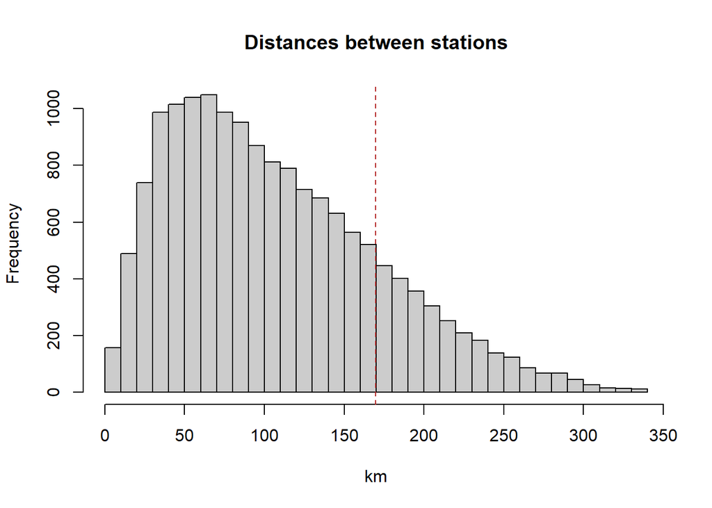

```r
hist(dd, breaks = 30, col = "grey80", main = "Distances between stations", xlab = "km")
abline(v = max(dd) / 2, col = "firebrick", lty = 2)
```

*Figure: histogram of the distances between all pairs of stations (km). The red line is half of the largest distance.*

The largest distance between two stations is 339 km. Half of the pairs are closer than 95 km and 90 % are closer than 200 km; there are few pairs at very large distances, and these pairs always involve the stations at the opposite ends of the area. We therefore stop at half of the largest distance, 170 km (red line). We cut the distance in 15 classes of about 11 km.

```r
cutoff <- max(D) / 2
width  <- cutoff / 15
v_raw <- variogram(totanno ~ 1,                    locations = ~ XUTM + YUTM, data = d80, cutoff = cutoff, width = width)
v_el  <- variogram(totanno ~ Quota,                locations = ~ XUTM + YUTM, data = d80, cutoff = cutoff, width = width)
v_xy  <- variogram(totanno ~ Quota + XUTM + YUTM,  locations = ~ XUTM + YUTM, data = d80, cutoff = cutoff, width = width)
min(v_raw$np)                                      # smallest number of pairs in a class
```

```
[1] 198
```

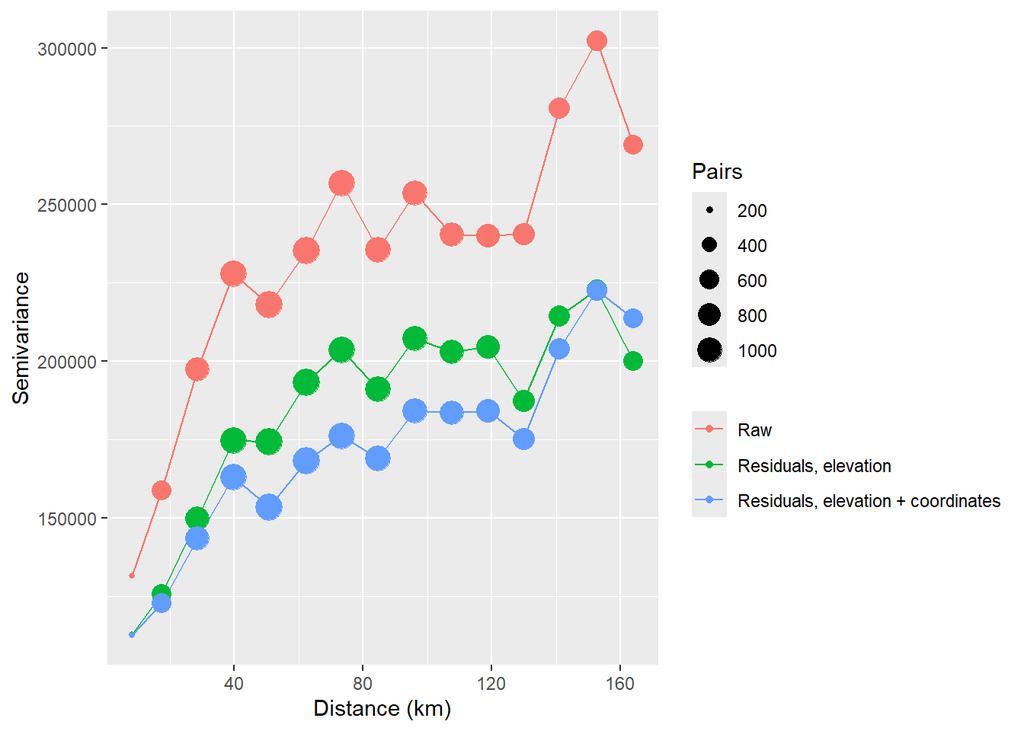

```r
vv <- rbind(cbind(v_raw, model = "Raw"),
            cbind(v_el,  model = "Residuals, elevation"),
            cbind(v_xy,  model = "Residuals, elevation + coordinates"))
ggplot(vv, aes(dist / 1000, gamma, colour = model)) +
  geom_line() + geom_point(aes(size = np)) +
  labs(x = "Distance (km)", y = "Semivariance", colour = NULL, size = "Pairs")
```

```r
# first classes of each variogram
round(cbind(dist_km = v_raw$dist / 1000, pairs = v_raw$np, raw = v_raw$gamma,
            elev = v_el$gamma, elev_xy = v_xy$gamma))[c(1:3, 8, 15), ]
```

```
     dist_km pairs    raw   elev elev_xy
[1,]       8   198 131500 112657  112407
[2,]      17   624 158710 125739  122626
[3,]      29   965 197363 149654  143265
[4,]      85  1078 235406 191099  168786
[5,]     164   606 269056 199884  213488
```

The first number is the smallest number of pairs in a class: 198, so all the classes have many pairs and the points of the variogram are reliable. The table shows five of the classes (distance in km, number of pairs and semivariance for the three variograms).

*Figure: semivariance against distance, for the raw rainfall and for the residuals after elevation and after elevation + coordinates. The size of the points is the number of pairs.*

The raw variogram starts at about 130 000 for the smallest distances (8 km) and rises to about 270 000 at 164 km: stations far from each other are more different than close stations. This is a sign of spatial dependence, but also of a trend, because it keeps rising and does not flatten. After removing the effect of elevation, the curve is lower everywhere (for example about 191 000 instead of 235 000 at 85 km), so elevation explains a part of the differences. With elevation and coordinates it is lower again at short and medium distances (169 000 at 85 km), but not at the largest ones. The curves still increase with the distance, so there is some spatial structure left that these variables do not explain. The lines only join the points to help reading: they are not fitted models.

To see if the structure of the residuals could just be chance, we shuffle the residuals of the elevation model among the stations 99 times. Each time we compute the variogram, and the grey band is the range of the 99 results: it shows what we get when there is no spatial dependence.

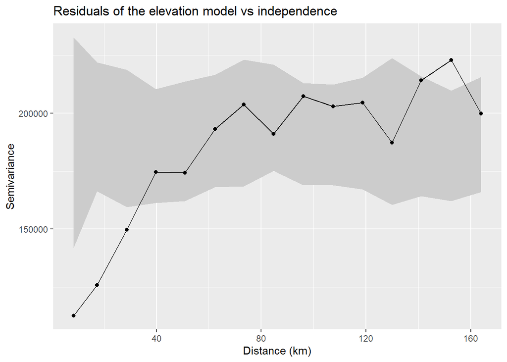

```r
set.seed(1980)
r_el <- residuals(fit_el)
sims <- replicate(99, {
  tmp <- d80; tmp$r <- sample(r_el)
  variogram(r ~ 1, locations = ~ XUTM + YUTM, data = tmp, cutoff = cutoff, width = width)$gamma[seq_len(nrow(v_el))]
})
r_all <- variogram(I(r_el) ~ 1, locations = ~ XUTM + YUTM, data = d80, cutoff = cutoff, width = width)
env <- data.frame(dist = r_all$dist, gamma = r_all$gamma,
                  lo = apply(sims, 1, min), hi = apply(sims, 1, max))
ggplot(env, aes(dist / 1000)) +
  geom_ribbon(aes(ymin = lo, ymax = hi), fill = "grey80") +
  geom_line(aes(y = gamma)) + geom_point(aes(y = gamma)) +
  labs(x = "Distance (km)", y = "Semivariance", title = "Residuals of the elevation model vs independence")
```

```r
n_below <- sum(env$gamma < env$lo)
```

*Figure: variogram of the residuals of the elevation model (line and points) and the band expected without spatial dependence (grey).*

3 classes of the observed variogram are below the grey band. These are classes where close stations are more alike than chance allows. So the residuals of the elevation model are still spatially dependent. This only tells us that the stations are not independent in space. It does not tell us if IDW makes good predictions: for that, we use cross-validation in the next part.

### 3. Choice of p in IDW

IDW predicts the rainfall at a point with a weighted mean of the stations, where the weights are $1/d^p$ ($d$ is the distance to the station). When p is large, the nearest stations count much more. To choose p, we remove each station in turn, predict it with the 177 others and compute the error. We keep the p with the smallest RMSE (root of the mean squared error), which is a proper score. We also compute a simple reference: predicting each station with the mean of the other stations.

```r
Dl <- D; diag(Dl) <- Inf                        # a station never predicts itself
loo_pred <- function(p) { W <- Dl^(-p); as.vector(W %*% z) / rowSums(W) }
loo_rmse <- function(p) sqrt(mean((z - loo_pred(p))^2))

p_grid <- seq(0.25, 8, by = 0.25)
cv <- data.frame(p = p_grid, RMSE = sapply(p_grid, loo_rmse))
p0 <- cv$p[which.min(cv$RMSE)]
opt <- optimize(loo_rmse, c(max(0.01, p0 - 0.25), p0 + 0.25))   # refinement around the minimum
p_opt <- opt$minimum

pred_cv  <- loo_pred(p_opt)
rmse_idw <- sqrt(mean((z - pred_cv)^2))
mae_idw  <- mean(abs(z - pred_cv))
rmse_ref <- sqrt(mean((z - (sum(z) - z) / (n - 1))^2))          # mean of the other stations
c(p_opt = p_opt, RMSE = rmse_idw, MAE = mae_idw, RMSE_mean_of_others = rmse_ref,
  skill = 1 - rmse_idw^2 / rmse_ref^2)
```

```
              p_opt                RMSE                 MAE RMSE_mean_of_others
          2.6226213         357.8547143         267.0683665         486.1477706
              skill
          0.4581527
```

```r
head(cv[order(cv$RMSE), ], 4)                   # best values of the grid
```

```
      p     RMSE
11 2.75 358.1365
10 2.50 358.1576
12 3.00 359.9808
9  2.25 361.0664
```

```r
cv$RMSE[cv$p %in% c(0.25, 1, 8)]
```

```
[1] 477.9460 434.5168 411.9557
```

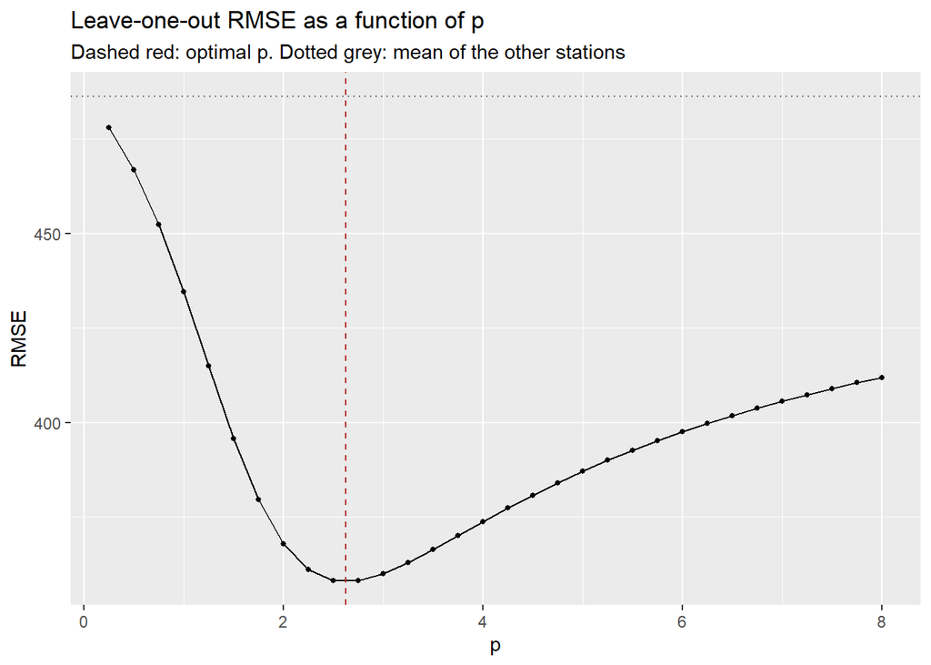

```r
ggplot(cv, aes(p, RMSE)) + geom_line() + geom_point(size = 1) +
  geom_vline(xintercept = p_opt, linetype = 2, colour = "firebrick") +
  geom_hline(yintercept = rmse_ref, linetype = 3, colour = "grey40") +
  labs(title = "Leave-one-out RMSE as a function of p",
       subtitle = "Dashed red: optimal p. Dotted grey: mean of the other stations")
```

*Figure: leave-one-out RMSE for each p (dashed red line = best p, dotted grey line = error of the simple reference).*

The first output gives the best p, the RMSE (358 mm) and the MAE (267 mm), which is the average absolute error. The reference has an RMSE of 486 mm, so IDW reduces the mean squared error by 46 % (the last number, `skill`, is this reduction written as a fraction). The table below shows the best values of p on the grid, and the three numbers after it are the RMSE for p = 0.25, 1 and 8. The curve starts high for small p (all the stations count almost the same, so the prediction is close to the mean), goes down to the minimum at p = 2.62, then goes up again for large p (only the closest station counts). The curve is flat around the minimum, so values of p close to 2.6 give almost the same result.

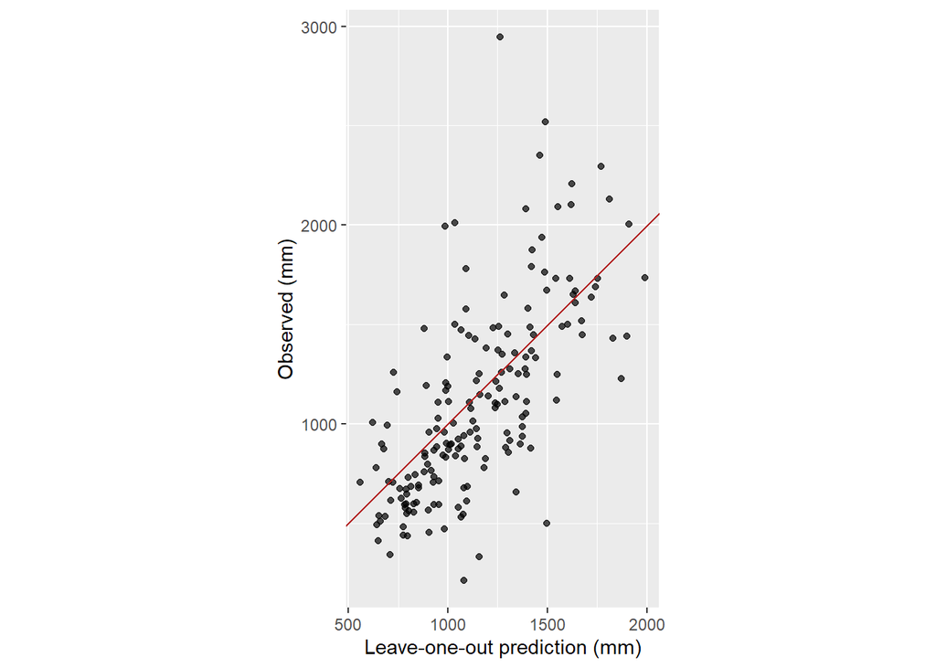

```r
ggplot(data.frame(obs = z, pred = pred_cv), aes(pred, obs)) +
  geom_point(alpha = 0.7) + geom_abline(colour = "firebrick") + coord_equal() +
  labs(x = "Leave-one-out prediction (mm)", y = "Observed (mm)")
```

*Figure: observed rainfall against the leave-one-out prediction. The red line is the line where prediction = observation.*

The points are around the red line, so IDW follows the general level of the rainfall. Some points are far from the line: these stations are very different from their neighbours, and IDW cannot predict them. The optimal p is **2.62**, with a cross-validation RMSE of 357.9 mm.

### 4. IDW map on the prediction grid

We predict the rainfall on the points of `grid` with p = 2.62. We also check our function against the `idw` function of the `gstat` package.

```r
idw_grid <- function(x0, y0, x, y, z, p) {
  d <- sqrt(outer(x0, x, "-")^2 + outer(y0, y, "-")^2)
  d[d < 1e-6] <- 1e-6                           # grid point on a station: its own value
  W <- d^(-p); as.vector(W %*% z) / rowSums(W)
}
grid$pred <- idw_grid(grid$XUTM, grid$YUTM, d80$XUTM, d80$YUTM, z, p_opt)

# check with the idw function of gstat
chk <- idw(totanno ~ 1, locations = ~ XUTM + YUTM, data = d80, newdata = grid, idp = p_opt, debug.level = 0)
max(abs(chk$var1.pred - grid$pred))
```

```
[1] 1.818989e-12
```

```r
summary(grid$pred)
```

```
   Min. 1st Qu.  Median    Mean 3rd Qu.    Max.
  327.7   779.6   959.8  1056.2  1287.6  2681.6
```

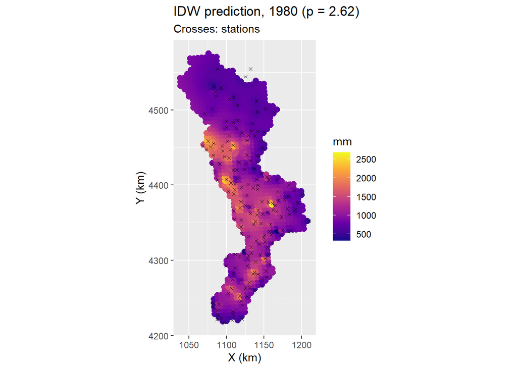

```r
ggplot() +
  geom_point(data = grid, aes(XUTM / 1000, YUTM / 1000, colour = pred), size = 2.5) +
  geom_point(data = d80, aes(XUTM / 1000, YUTM / 1000), shape = 4, size = 1) +
  scale_colour_viridis_c(option = "C", name = "mm") + coord_equal() +
  labs(x = "X (km)", y = "Y (km)", title = paste0("IDW prediction, 1980 (p = ", round(p_opt, 2), ")"),
       subtitle = "Crosses: stations")
```

The difference with `gstat::idw` is about 10⁻¹² (the first number), so the two give the same predictions. The summary shows the predicted rainfall on the grid: from about 328 mm to about 2682 mm, with a median of about 960 mm.

*Figure: IDW prediction on the grid (colour); the crosses are the stations.*

The map is smooth and follows the stations: the high values are around the groups of stations with a lot of rain, and the low values in the zones where stations have little rain. Around each station, the prediction is close to its measure.

```r
grid$d_nn <- apply(sqrt(outer(grid$XUTM, d80$XUTM, "-")^2 + outer(grid$YUTM, d80$YUTM, "-")^2), 1, min) / 1000
summary(grid$d_nn)                              # distance (km) to the nearest station
```

```
   Min. 1st Qu.  Median    Mean 3rd Qu.    Max.
 0.4144  3.5833  5.6500  7.5591  8.8758 46.4441
```

```r
mean(grid$Quota > max(d80$Quota))               # share of grid points higher than the highest station
```

```
[1] 0.03283582
```

The first output is the distance (in km) between each grid point and the nearest station: it is 5.7 km for half of the points, but it goes up to 46 km for a few of them. In these places the map is only an extension of far stations and is less reliable. The last number says that 3 % of the grid points are higher than the highest station, and IDW never predicts values outside the range of the observed rainfall: the highest places are probably under-estimated.

## Comparison of the two prompts

We compare the p and the cross-validation RMSE obtained with the two answers.

```r
c(p_weak = p_weak, RMSE_weak = loo_rmse(p_weak), p_good = round(p_opt, 2), RMSE_good = rmse_idw)
```

```
   p_weak RMSE_weak    p_good RMSE_good
   3.0000  359.9808    2.6200  357.8547
```

With the weak prompt (p = 3) the RMSE is 360 mm, and with the good prompt (p = 2.62) it is 358 mm. The difference is very small, so the choice of p is not what changes the most between the two answers. The difference is in the rest of the analysis.

|  | Weak prompt | Good prompt |
| --- | --- | --- |
| Exploratory analysis | Regression on elevation and coordinates | Short: distribution, elevation (correlation and test), map |
| Spatial dependence | Not studied | Variograms (raw and residuals), number of pairs, band without dependence |
| Choice of p | Whole values from 1 to 5 | Fine grid, RMSE |
| Reference | None | Mean of the other stations |
| Stations | Not discussed | All 178 kept, “Puglia” stations assigned |
| Checks | None | Each conclusion can be checked |

The weak prompt gives a working analysis quickly, but the agent decides alone what to do and what to leave out: no variogram, a rough search for p, and nothing about the stations. The good prompt gives the data, the stations to keep, the score and the checks, so the answer is more precise and easier to verify. In both cases we have to read the answer carefully: the AI can run an analysis, but the choices (which stations, which score, which maximum distance) must be justified by us.

# Conclusion: the three years

We apply the same checks to the three years, to see what stays the same and what changes.

```r
load("../data/RainData.RData")          # original data
summ <- do.call(rbind, lapply(c(1973, 1974, 1980), function(y) {
  d <- subset(dati, anno == y); zz <- d$totanno; nn <- length(zz)
  Dm <- as.matrix(dist(cbind(d$XUTM, d$YUTM))); diag(Dm) <- Inf
  rm <- function(p) { W <- Dm^(-p); sqrt(mean((zz - as.vector(W %*% zz) / rowSums(W))^2)) }
  pg <- seq(0.25, 8, by = 0.25); p0 <- pg[which.min(sapply(pg, rm))]
  op <- optimize(rm, c(max(0.01, p0 - 0.25), p0 + 0.25))
  ref <- sqrt(mean((zz - (sum(zz) - zz) / (nn - 1))^2))   # mean of the other stations
  dg <- sqrt(outer(grid$XUTM, d$XUTM, "-")^2 + outer(grid$YUTM, d$YUTM, "-")^2)
  Wg <- dg^(-op$minimum); pg_map <- as.vector(Wg %*% zz) / rowSums(Wg)   # IDW map on the grid
  data.frame(Year = y, Stations = nn, Mean_rain = round(mean(zz)),
             Cor_elevation = round(cor(d$Quota, zz), 2),
             R2_elevation = round(summary(lm(zz ~ d$Quota))$r.squared, 2),
             Cor_lat = round(cor(d$Lat10, zz), 2), Cor_lon = round(cor(d$Lon10, zz), 2),
             Optimal_p = round(op$minimum, 2), LOO_RMSE = round(op$objective),
             RMSE_mean_of_others = round(ref),
             Reduction_MSE_pct = round(100 * (1 - op$objective^2 / ref^2)),
             Cor_map_elevation = round(cor(pg_map, grid$Quota), 2))
}))
knitr::kable(summ)
```

| Year | Stations | Mean_rain | Cor_elevation | R2_elevation | Cor_lat | Cor_lon | Optimal_p | LOO_RMSE | RMSE_mean_of_others | Reduction_MSE_pct | Cor_map_elevation |
| --- | --- | --- | --- | --- | --- | --- | --- | --- | --- | --- | --- |
| 1973 | 188 | 1241 | 0.51 | 0.26 | -0.19 | 0.14 | 3.13 | 309 | 465 | 56 | 0.35 |
| 1974 | 187 | 973 | 0.40 | 0.16 | -0.04 | -0.22 | 3.45 | 255 | 408 | 61 | 0.44 |
| 1980 | 178 | 1105 | 0.43 | 0.19 | 0.00 | -0.18 | 2.62 | 358 | 486 | 46 | 0.41 |

The table gives, for each year, the number of stations, the mean annual rainfall (mm), the correlation and the R² of the rainfall with the elevation, the correlation with the latitude and the longitude, the optimal p of the IDW (the same procedure for the three years: leave-one-out RMSE), the cross-validation RMSE (mm), the RMSE of the simple reference (mean of the other stations), the reduction of the mean squared error obtained with IDW, and the correlation between the IDW map and the elevation of the grid points.

**1) Exploratory analysis.** In the three years the rainfall increases with the elevation (correlation from 0.4 to 0.51, all significant), which is what we expect, but elevation only explains 16 to 26 % of the differences between stations. The latitude and the longitude have weak correlations that change from one year to the other, so they do not give a stable effect. The variograms increase with the distance: close stations are more alike than distant ones. In 1973 and 1980, where we looked at it, part of this structure is still there once the elevation is taken into account. The level of rain changes a lot between years (1974 is the driest year, with a mean of 973 mm against 1241 mm in 1973).

**2) Choice of p.** The optimal p is of the same order each year (3.13 in 1973, 3.45 in 1974, 2.62 in 1980), so the nearest stations count much more than the far ones. The cross-validation RMSE is between 255 and 358 mm, and IDW reduces the mean squared error by 46 to 61 % compared with the mean of the other stations: IDW predicts better than a very simple prediction in each year, and this is shown by the cross-validation, not by the spatial dependence alone.

**3) Maps.** The three maps show the same pattern: the predicted rainfall is higher where the elevation is higher (correlation between the map and the elevation of the grid points from 0.35 to 0.44), and the surfaces are smooth. The 1974 map was drawn on a regular grid cut to the borders of Italy, and the 1973 and 1980 maps on the given prediction grid, so the maps do not cover exactly the same points. Differences between the maps should be read carefully, because they come both from the rain of the year and from the stations available (188, 187 and 178 stations, not exactly the same ones). Where the grid is far from the stations, the map is only an extension of the nearest stations.

**4) Prompts.** For each year, the prompt with more information (data, steps, score to use, way to check the results) gives a more precise and complete analysis than the weak prompt. In 1973 and 1980 the good prompt added a variogram, a fine search of p and a comparison with a simple reference. In 1974 the prompts were used to write one function at a time, and the first answers had to be completed by a second, more precise prompt (a trend line on the scatter plot, a map focused on the study area, the RMSE instead of the MSE). In all cases, the AI answer has to be read and checked: the choices (stations kept, score, distances) must be justified by us.